# COVID genome

# Kneaddata/Bowtie2

Make SARS-COV-2 database:

```bash
wget ftp://ftp.ncbi.nlm.nih.gov/genomes/all/GCF/009/858/895/GCF_009858895.2_ASM985889v3/GCF_009858895.2_ASM985889v3_genomic.fna.gz
bowtie2-build GCF_009858895.2_ASM985889v3_genomic.fna.gz SARS-COV-2
```

Run with the cat_reads MG samples:

```bash
parallel -j 1 --link --progress 'kneaddata -i {1} -i {2} -o kneaddata_out_covid/ \
-db covid_ref_genome/ --trimmomatic /home/robyn/tools/Trimmomatic-0.39/ \
-t 12 --trimmomatic-options "SLIDINGWINDOW:4:20 MINLEN:50" \
--bowtie2-options "--very-sensitive --dovetail" --remove-intermediate-output' \
 ::: cat_lanes/*_R1.fastq.gz ::: cat_lanes/*_R2.fastq.gz

kneaddata_read_count_table --input kneaddata_out_covid/ --output kneaddata_read_counts_covid_genome.txt
```

Resulting sample sizes:

```python
import pandas as pd
import matplotlib.pyplot as plt

samples = pd.read_csv('/Users/robynwright/Documents/OneDrive/Langille_Lab_postdoc/COVID/kneaddata_read_counts_covid_genome.txt', sep='\t', header=0, index_col=0)
print(samples)
```

[output not shown]

```python
nonzero = {'cDNA-N1-pos_S75_R1_kneaddata':103, 'cDNA-N2-pos_S76_R1_kneaddata':130, 'cDNA-N3-pos_S77_R1_kneaddata':1.1, 'cDNA-N4-pos_S78_R1_kneaddata':6.9, 'cDNA-N5-pos_S79_R1_kneaddata':20, 'cDNA-O1-pos_S80_R1_kneaddata':1.5, 'cDNA-O2-pos_S61_R1_kneaddata':118, 'cDNA-O3-pos_S62_R1_kneaddata':23, 'cDNA-O4-pos_S63_R1_kneaddata':3.4, 'cDNA-O5-pos_S64_R1_kneaddata':15}

plt.figure(figsize=(10,3))
ax1 = plt.subplot(111)

count = 0
names, x = [], []
for sample in samples.index.values:
  if sample in nonzero:
    ax1.bar(count, nonzero[sample], color='k')
  x.append(count)
  names.append(sample.split('_')[0])
  count += 1
```

```python
plt.xticks(x, names, rotation=90)
```

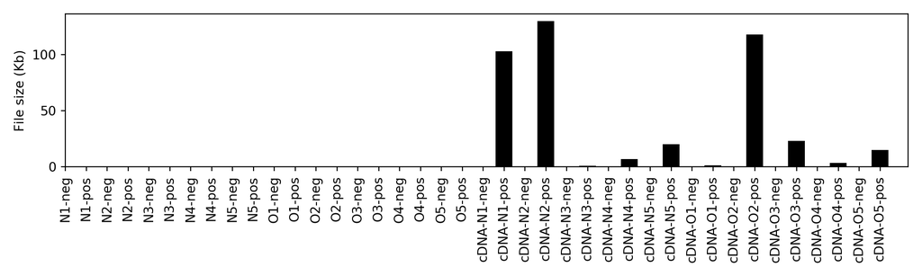

```python
plt.ylabel('File size (Kb)')
plt.tight_layout()
plt.show()
```

# metaSPADES

## Test

Needs single short-read library, with paired-end reads

Install:

```bash
#Check dependencies
g++ --version
g++ (Ubuntu 5.5.0-12ubuntu1~16.04) 5.5.0 20171010
cmake --version
cmake version 3.5.1
conda install zlib #still isn't showing with which or --version, but it says it installed so I'll try the rest anyway.
conda install libbz2 #also didn't install, so trying anyway

wget http://cab.spbu.ru/files/release3.14.1/SPAdes-3.14.1.tar.gz
tar -xzf SPAdes-3.14.1.tar.gz
cd SPAdes-3.14.1

PREFIX=/home/robyn/anaconda3/ ./spades_compile.sh
```

Test:

```bash
/home/robyn/anaconda3/bin/spades.py --test
```

Input: - paired end reads (using fastq files from concatenating lanes)

Test single sample:

```bash
/home/robyn/anaconda3/bin/spades.py -o test_spades_out --meta -1 cat_lanes/cDNA-N1-pos_S75_R1.fastq.gz -2 cat_lanes/cDNA-N1-pos_S75_R2.fastq.gz -t 12
```

Run:

```bash
/home/robyn/anaconda3/bin/spades.py -o test_spades_out --meta -1 cat_lanes/cDNA-N1-pos_S75_R1.fastq.gz -2 cat_lanes/cDNA-N1-pos_S75_R2.fastq.gz -t 12
```

Took ~5 hours to run using 12 threads on vulcan.

Install MetaQUAST:

```bash
wget https://downloads.sourceforge.net/project/quast/quast-5.0.2.tar.gz
tar -xzf quast-5.0.2.tar.gz
cd quast-5.0.2
```

Seems to work fine.

Run on the sample:

```bash
python /home/robyn/tools/quast-5.0.2/metaquast.py test_spades_out/contigs.fasta --references-list reference-list.txt --threads 10
```

This gives the following COVID genome alignment graph:

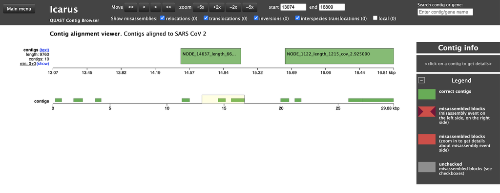

The largest contig that aligned was 2747 and the total aligned length was 9760 (32.6% COVID genome coverage).

## All samples

Pipeline used in [Virome characterisation comparison paper](https://microbiomejournal.biomedcentral.com/articles/10.1186/s40168-019-0626-5):  
1. Trimmomatic  
2. MetaSPAdes  
3. MetaQUAST

Because MetaSPAdes took quite a long time to run with the whole sample, I’m going to do this first with “contam” output from Bowtie2 above, so those reads that mapped to the COVID genome (i.e. skipping the Trimmomatic step for not).

**MetaSPAdes:**

```bash
parallel -j 1 --link --progress '/home/robyn/anaconda3/bin/spades.py --meta -1 {1} -2 {2} -t 12 -o metaSPADES/{1/.}' ::: kneaddata_covid_contam/*_1.fastq ::: kneaddata_covid_contam/*_2.fastq
```

**MetaQUAST:**

```bash
parallel -j 1 --link --progress 'python /home/robyn/tools/quast-5.0.2/metaquast.py {1}/contigs.fasta --references-list reference-list.txt --threads 10 -o quast_results/{1/}' ::: metaSPADES/*
```

**Alignment summary:**

```python
samples = ['N1', 'N1', 'N2', 'N4', 'N5', 'O2', 'O3', 'O4', 'O5']
largest_aligned_contig = [2747, 2721, 4016, 0, 4745, 4743, 502, 0, 0]
total_aligned = [9760, 8536, 17872, 0, 26891, 12041, 502, 0, 0]
total_perc_aligned = [32.6, 28.519, 59.8, 0, 89.7, 40.299, 1.68, 0, 0]
colors = ['w', 'r', 'r', 'r', 'r', 'b', 'b', 'b', 'b']
label = ['Largest aligned contig (bp)', 'Total aligned (bp)', 'COVID genome coverage (%)']

plt.figure(figsize=(10,4))
ax1, ax2, ax3 = plt.subplot(131), plt.subplot(132), plt.subplot(133)
ax = [ax1, ax2, ax3]
x = []
for a in range(len(samples)):
  ax1.bar(a, largest_aligned_contig[a], color=colors[a], width=0.8, edgecolor='k')
  ax2.bar(a, total_aligned[a], color=colors[a], width=0.8, edgecolor='k')
  ax3.bar(a, total_perc_aligned[a], color=colors[a], width=0.8, edgecolor='k')
  x.append(a)
```

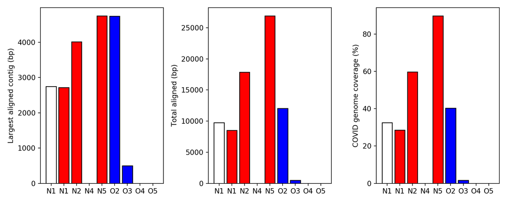

```python
for a in range(len(ax)):
  plt.sca(ax[a])
  plt.xticks(x, samples)
  plt.ylabel(label[a])

plt.tight_layout()
plt.show()
```

Note that the white N1 bar is for the test above (i.e. the whole sample was assembled and aligned to the COVID genome) while the red N1 bar is for only the reads that bowtie2 aligned to the COVID genome. For reference, the COVID genome is 29,882 bp.

So the sample with the highest % aligned is N5:

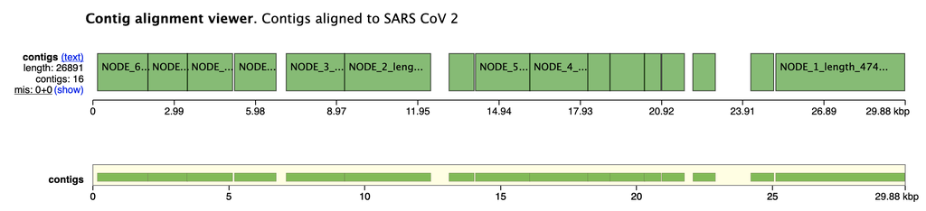

# ANVIO

## Install ANVIO

Following the instructions [here](https://merenlab.org/2016/06/26/installation-v2/).

```bash
conda update conda
conda create -y --name anvio-6.2 python=3.6
conda activate anvio-6.2
conda install -y -c conda-forge -c bioconda anvio==6.2
```

Check installation:

```bash
conda list | grep anvio-minimal | grep 6.2 | awk '{print $3}'
```

One more step:

```bash
conda remove -y --force anvio-minimal
conda install -y -c bioconda -c conda-forge anvio-minimal==6.2=py_1
```

Test run:

```bash
anvi-self-test --suite mini
```

## TARA oceans MAGs

Following the tutorial [here](https://merenlab.org/data/tara-oceans-mags/).